# Ford Gobike Data Analysis

# The structure of the dataset:

After dropping rows with missing values, the dataset contains 15 features (columns) and 174952 entries (rows).

### The main questions I want to answer:

-what is the average trip duration range?

-what are the days of the week with highest and lowest number of trips?

-what is the average age of members?

-what is average age per customers and subscribers?

-what is the ratio between different genders as customers ad subscribers?

-what is the average trip duration per customers compared to subscribers, and who takes more time in average?

# Univariate exploration:

I'll look at the main feature of interest, that's trip duration. but first, I'll convert seconds to minutes in the duration_sec column and store the result in another column.

Now I'll look at the distribution of trip duration in the dataset.

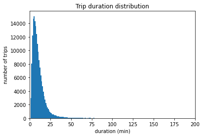

Since the distribution is very skewed to the right, I should scale the x axis.

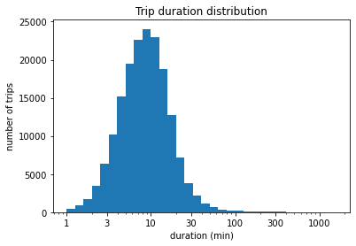

The distribution shows that most trips take approximately 5-25 minutes.

Next, I'll answer the question about the days of the week with the most and least trips, but to answer this question, I need to extract days from the start_time column.

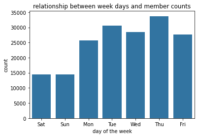

As shown in the bar chart, the day of the week with the most number of trips is thursday, interestingly the days with the least numbers of trips are saturday and sunday. This might indicate that more than half of the trips are work related. since in the weekends the number of trips drops significantly (by approximately half of the total average).

Now I'll try to answer another question, which is the difference between customers and subscribers in numbers.

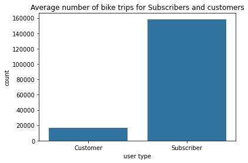

This bar chart shows that most members in the datasets are subscribers. Now let's see the age distribiution of members, but first I'll calculate the age of members in a new column "age".

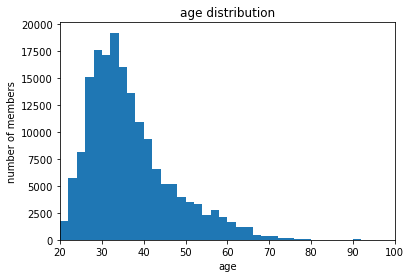

Looks like most members are between the age of 25-40.

## Bivariate exploration:

let's take a look at the average age per customers and subscribers using box plots.

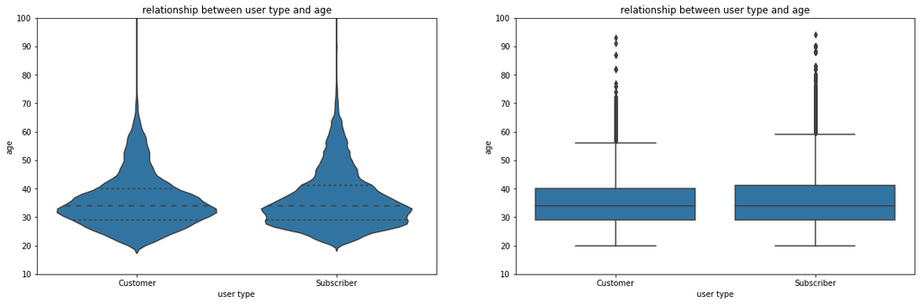

These plots suggest that most members either customers or subscribers, are between the age of 27-40

Now let's see the relationship between age and trip duration in minutes using a heat map.

[figure not shown]

This heat map shows that most members are between the age of 25-40 and they take around 5-25 minutes in their trips.

let's find out the average trip duration among customers compared to subscribers using box plots and violin plots.

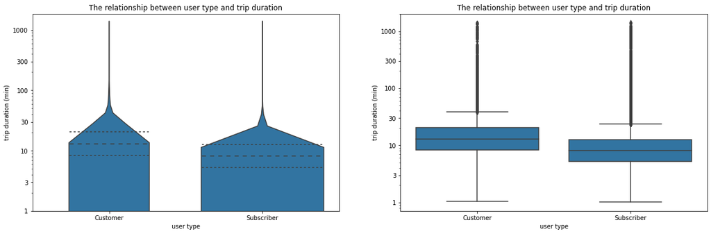

# Multivariate exploration:

Now let's see the ratio between different genders as customers and subscribers.

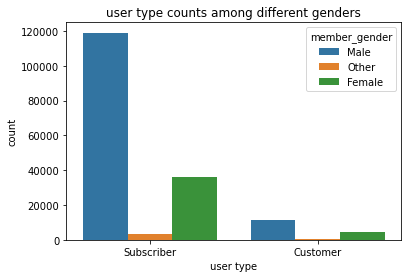

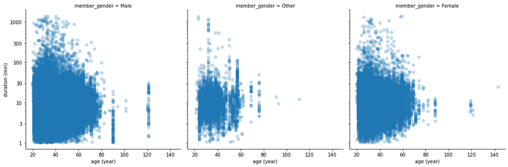

Interestingly, there's a jump in trip duration for the (other) gender before the age of 60.